# Rail Accessibility and House Prices in Greater Manchester: An OLS and GWR Analysis

GitHub repository：https://github.com/TanWANG41/gm-rail-house-prices.git

## 1. Introduction

Access to transport is one way in which location becomes reflected in the housing market. In a hedonic view of property prices, the price paid for a dwelling is not only a payment for the building itself, but also for its surrounding attributes, including neighbourhood conditions and accessibility (Rosen, 1974). This is particularly relevant in urban areas where households face trade-offs between housing cost, commuting convenience and access to jobs and services.

Greater Manchester provides a suitable case because housing and transport conditions vary across the city-region rather than following one simple pattern. Wong et al. (2015) show that housing affordability and transport accessibility differ across the ten Greater Manchester local authorities, and argue that these issues are linked to urban growth, spatial competitiveness and everyday quality of life. Within this setting, distance to rail and Metrolink stations provides a practical way to construct a distance-based proxy for rail-based public transport accessibility. These stations are fixed, visible access points in the transport network, and previous research shows why they may matter for property prices: they can reduce commuting costs and attract local activity, but may also bring negative local externalities (Bowes and Ihlanfeldt, 2001). The relationship is therefore unlikely to be the same everywhere.

This study therefore asks whether residential transaction prices in Greater Manchester vary with distance to the nearest rail or Metrolink station, and whether this relationship is spatially uneven. In the analysis, this station-distance measure is used as a proxy for rail-based public transport accessibility. The analysis combines 2023–2025 residential transactions with postcode locations, neighbourhood deprivation, city-centre distance and station distance. OLS is used to estimate the overall association, while GWR is used to examine whether the station-distance coefficient varies across neighbourhoods (Fotheringham et al., 2002). The results are treated as evidence of association, not causality.

## 2. Data Source

The main housing dataset is HM Land Registry’s Price Paid Data for residential transactions between 2023 and 2025 (HM Land Registry, 2026). This source provides transaction prices, postcodes, property type, new-build status, tenure and transaction date. Since the Price Paid Data do not provide direct spatial coordinates, transaction postcodes were linked to the ONS Postcode Directory (Office for National Statistics, 2025a).

Local Authority District boundaries were used to define the Greater Manchester study area and support spatial filtering (Office for National Statistics, 2025b), while LSOA boundaries were used for neighbourhood-level mapping and spatial aggregation (Office for National Statistics, 2024).

Rail-based public transport accessibility was measured using the Metrolink Stops and Rail Stations dataset (Transport for Greater Manchester, 2024). This dataset provides the location of rail and Metrolink stops, allowing the distance from each residential transaction postcode to the nearest station to be calculated.

Neighbourhood deprivation was added using the LSOA-level Index of Multiple Deprivation 2025 (Ministry of Housing, Communities and Local Government, 2025), since house prices may also reflect wider neighbourhood conditions. The final dataset therefore combines transaction prices, property characteristics, postcode location, rail/Metrolink accessibility, deprivation and distance to Manchester city centre.

## 3. Data Processing and Feature Engineering

The raw transaction files for 2023, 2024 and 2025 were first imported and merged into one property-level table. Before any spatial matching was carried out, records with missing postcodes were removed, since postcode was the link between the transaction data and geographic information. The sample was also restricted to standard residential sales by keeping the four main property types, detached, semi-detached, terraced and flat, and removing non-standard Price Paid entries. This step was used to keep the modelling sample closer to ordinary residential market transactions.

Postcodes were then cleaned by removing spaces and converting all characters to uppercase. The cleaned postcodes were matched to postcode directory records to add British National Grid coordinates, LSOA codes and local authority identifiers. Transactions without a valid coordinate match were dropped. After this join, the data were spatially filtered to Greater Manchester and converted into point geometries using EPSG:27700. This projected coordinate system was used because the following distance calculations needed to be measured in metres rather than degrees.

The main accessibility variable was created from the rail and Metrolink station points. Station locations were converted to the same coordinate system as the transaction points. A nearest-neighbour spatial join was then used to identify the closest rail or Metrolink station for each transaction. The resulting straight-line distance was converted from metres to kilometres and stored as `nearest_station_dist_km`. This variable measures proximity to the nearest station, not actual journey time or walking distance.

Neighbourhood deprivation was joined through the transaction’s LSOA code. The IMD decile was recoded as `imd_deprivation_decile`, where higher values represent higher deprivation. This made the coefficient easier to interpret in the regression models. A second spatial control, `city_centre_dist_km`, was calculated as the straight-line distance from each transaction point to Manchester Piccadilly, used here as a simple proxy for centrality.

Finally, transaction price was transformed into `log_price` to reduce the influence of the right-skewed price distribution. Price observations below the 1st percentile and above the 99th percentile were removed to limit the effect of unusual transactions. Categorical variables for property type, new-build status, tenure and transaction year were converted into dummy variables. The final modelling dataset contained 93,842 complete residential transactions with price, property attributes, station distance, deprivation, city-centre distance and spatial coordinates.

```python
import pandas as pd
from pathlib import Path
import numpy as np
import geopandas as gpd
import shapely
import matplotlib.pyplot as plt
import matplotlib.ticker as mtick
from matplotlib.lines import Line2D
from matplotlib.colors import TwoSlopeNorm
import statsmodels.api as sm
import sklearn
from libpysal.weights import Queen
from esda.moran import Moran
from mgwr.gwr import GWR
from mgwr.sel_bw import Sel_BW
import warnings
warnings.filterwarnings("ignore")
```

```python
DATA_DIR = Path(".")

files = {
    2023: DATA_DIR / "pp-2023.csv",
    2024: DATA_DIR / "pp-2024.csv",
    2025: DATA_DIR / "pp-2025.csv"
}
```

```python
ppd_columns = [
    "transaction_id",
    "price",
    "date_of_transfer",
    "postcode",
    "property_type",
    "old_new",
    "duration",
    "paon",
    "saon",
    "street",
    "locality",
    "town_city",
    "district",
    "county",
    "ppd_category_type",
    "record_status"
]
```

```python
def read_ppd(file_path, source_year):
    df = pd.read_csv(
        file_path,
        header=None,
        names=ppd_columns,
        dtype={
            "transaction_id": "string",
            "postcode": "string",
            "property_type": "category",
            "old_new": "category",
            "duration": "category",
            "town_city": "string",
            "district": "string",
            "county": "string",
            "ppd_category_type": "category",
            "record_status": "category"
        }
    )


    df["date_of_transfer"] = pd.to_datetime(df["date_of_transfer"], errors="coerce")
    df["price"] = pd.to_numeric(df["price"], errors="coerce")
    df["transaction_year"] = df["date_of_transfer"].dt.year
    df["source_file_year"] = source_year

    return df
```

```python
ppd_list = []

for year, file in files.items():
    df_year = read_ppd(file, year)
    ppd_list.append(df_year)

ppd = pd.concat(ppd_list, ignore_index=True)
```

```python
missing_summary = ppd[
    ["price", "date_of_transfer", "postcode", "property_type", "old_new", "duration"]
].isna().sum()

missing_summary
```

```
price                  0
date_of_transfer       0
postcode            6734
property_type          0
old_new                0
duration               0
dtype: int64
```

```python
output_file = DATA_DIR / "ppd_2023_2025_combined_raw.csv"

ppd.to_csv(output_file, index=False)

print(f"Saved to: {output_file}")
```

```
Saved to: ppd_2023_2025_combined_raw.csv
```

```python
ppd_work = ppd.copy()

rows_original = len(ppd_work)

ppd_work["postcode_clean"] = (
    ppd_work["postcode"]
    .astype("string")
    .str.upper()
    .str.replace(r"\s+", "", regex=True)
    .str.strip()
)

ppd_work = ppd_work.dropna(subset=["postcode_clean"]).copy()

residential_types = ["D", "S", "T", "F"]

ppd_work = ppd_work[
    (ppd_work["property_type"].isin(residential_types)) &
    (ppd_work["ppd_category_type"] == "A")
].copy()

for col in ["property_type", "old_new", "duration", "ppd_category_type"]:
    if hasattr(ppd_work[col], "cat"):
        ppd_work[col] = ppd_work[col].cat.remove_unused_categories()

rows_cleaned = len(ppd_work)

print(f"Original rows: {rows_original:,}")
print(f"Cleaned rows: {rows_cleaned:,}")
print(f"Rows removed: {rows_original - rows_cleaned:,}")
```

```
Original rows: 2,635,771
Cleaned rows: 2,186,122
Rows removed: 449,649
```

```python
keep_cols = [
    "transaction_id",
    "price",
    "date_of_transfer",
    "transaction_year",
    "postcode",
    "postcode_clean",
    "property_type",
    "old_new",
    "duration",
    "town_city",
    "district",
    "county",
    "ppd_category_type"
]

ppd_clean = ppd_work[keep_cols].copy()
```

```python
print("Year counts:")
display(ppd_clean["transaction_year"].value_counts().sort_index())

print("Property type counts:")
display(ppd_clean["property_type"].value_counts())

print("PPD category type counts:")
display(ppd_clean["ppd_category_type"].value_counts())
```

```
Year counts:
```

```
transaction_year
2023    707319
2024    760269
2025    718534
Name: count, dtype: int64
```

```
Property type counts:
```

```
property_type
S    648391
T    595806
D    560055
F    381870
Name: count, dtype: int64
```

```
PPD category type counts:
```

```
ppd_category_type
A    2186122
Name: count, dtype: int64
```

```python
output_file = DATA_DIR / "ppd_2023_2025_clean_for_postcode_match.csv"

ppd_clean.to_csv(output_file, index=False)

print(f"Saved to: {output_file}")
```

```
Saved to: ppd_2023_2025_clean_for_postcode_match.csv
```

```python
ONSPD_DIR = DATA_DIR / "ONSPD_MAY_2025"

onspd_files = list(ONSPD_DIR.rglob("*.csv"))

onspd_file = [
    f for f in onspd_files
    if "ONSPD" in f.name.upper() and "UK" in f.name.upper()
][0]

print(f"ONSPD file found: {onspd_file}")
```

```
ONSPD file found: ONSPD_MAY_2025/Data/ONSPD_MAY_2025_UK.csv
```

```python
onspd_cols = pd.read_csv(onspd_file, nrows=0).columns.tolist()

def find_first_existing(possible_cols, available_cols):
    for col in possible_cols:
        if col in available_cols:
            return col
    return None

postcode_col = find_first_existing(["pcds", "pcd2", "pcd"], onspd_cols)
east_col = find_first_existing(["oseast1m", "easting"], onspd_cols)
north_col = find_first_existing(["osnrth1m", "northing"], onspd_cols)
lsoa_col = find_first_existing(["lsoa21", "lsoa"], onspd_cols)
lad_col = find_first_existing(["oslaua", "laua", "lad"], onspd_cols)

selected_cols = {
    "postcode": postcode_col,
    "easting": east_col,
    "northing": north_col,
    "lsoa": lsoa_col,
    "lad": lad_col
}

print("Selected ONSPD columns:")
print(selected_cols)

usecols = [postcode_col, east_col, north_col, lsoa_col, lad_col]

onspd = pd.read_csv(
    onspd_file,
    usecols=usecols,
    dtype="string",
    low_memory=False
)

onspd = onspd.rename(columns={
    postcode_col: "postcode",
    east_col: "easting",
    north_col: "northing",
    lsoa_col: "lsoa_code",
    lad_col: "lad_code"
})

onspd["postcode_clean"] = (
    onspd["postcode"]
    .astype("string")
    .str.upper()
    .str.replace(r"\s+", "", regex=True)
    .str.strip()
)

onspd["easting"] = pd.to_numeric(onspd["easting"], errors="coerce")
onspd["northing"] = pd.to_numeric(onspd["northing"], errors="coerce")

onspd = (
    onspd
    .dropna(subset=["postcode_clean", "easting", "northing", "lsoa_code", "lad_code"])
    .drop_duplicates(subset=["postcode_clean"])
    .copy()
)

print(f"Cleaned ONSPD rows: {len(onspd):,}")
```

```
Selected ONSPD columns:
{'postcode': 'pcds', 'easting': 'oseast1m', 'northing': 'osnrth1m', 'lsoa': 'lsoa21', 'lad': 'oslaua'}
Cleaned ONSPD rows: 2,690,877
```

```python
rows_before_match = len(ppd_clean)

ppd_matched = ppd_clean.merge(
    onspd[["postcode_clean", "easting", "northing", "lsoa_code", "lad_code"]],
    on="postcode_clean",
    how="left"
)

matched_count = ppd_matched["easting"].notna().sum()
unmatched_count = ppd_matched["easting"].isna().sum()
match_rate = matched_count / len(ppd_matched) * 100

ppd_geo = ppd_matched.dropna(
    subset=["easting", "northing", "lsoa_code", "lad_code"]
).copy()

match_summary = pd.DataFrame({
    "step": [
        "PPD records before matching",
        "Matched records",
        "Unmatched records removed",
        "PPD records after matching"
    ],
    "records": [
        rows_before_match,
        matched_count,
        unmatched_count,
        len(ppd_geo)
    ]
})

display(match_summary)

print(f"Postcode match rate: {match_rate:.2f}%")
```

|  | step | records |
| --- | --- | --- |
| 0 | PPD records before matching | 2186122 |
| 1 | Matched records | 2184703 |
| 2 | Unmatched records removed | 1419 |
| 3 | PPD records after matching | 2184703 |

```
Postcode match rate: 99.94%
```

```python
print("Missing values after postcode matching:")
display(ppd_geo[["easting", "northing", "lsoa_code", "lad_code"]].isna().sum())

output_file = DATA_DIR / "ppd_2023_2025_postcode_matched.csv"

ppd_geo.to_csv(output_file, index=False)

print(f"Saved to: {output_file}")
```

```
Missing values after postcode matching:
```

```
easting      0
northing     0
lsoa_code    0
lad_code     0
dtype: int64
```

```
Saved to: ppd_2023_2025_postcode_matched.csv
```

```python
gm_lad_codes = {
    "E08000001": "Bolton",
    "E08000002": "Bury",
    "E08000003": "Manchester",
    "E08000004": "Oldham",
    "E08000005": "Rochdale",
    "E08000006": "Salford",
    "E08000007": "Stockport",
    "E08000008": "Tameside",
    "E08000009": "Trafford",
    "E08000010": "Wigan"
}

rows_before_gm_filter = len(ppd_geo)

ppd_gm = ppd_geo[ppd_geo["lad_code"].isin(gm_lad_codes.keys())].copy()
ppd_gm["lad_name"] = ppd_gm["lad_code"].map(gm_lad_codes)

print(f"Rows after Greater Manchester filter: {len(ppd_gm):,}")
```

```
Rows after Greater Manchester filter: 95,754
```

```python
gm_lad_summary = (
    ppd_gm["lad_name"]
    .value_counts()
    .rename_axis("local_authority")
    .reset_index(name="transactions")
    .sort_values("local_authority")
)


validation_summary = pd.DataFrame({
    "check": [
        "Number of Greater Manchester LADs",
        "Missing LSOA codes",
        "Unique LSOAs",
        "Total GM transactions"
    ],
    "value": [
        ppd_gm["lad_name"].nunique(),
        ppd_gm["lsoa_code"].isna().sum(),
        ppd_gm["lsoa_code"].nunique(),
        len(ppd_gm)
    ]
})

display(gm_lad_summary)
display(validation_summary)
```

|  | local_authority | transactions |
| --- | --- | --- |
| 4 | Bolton | 9454 |
| 9 | Bury | 6710 |
| 0 | Manchester | 13897 |
| 8 | Oldham | 6710 |
| 7 | Rochdale | 7076 |
| 3 | Salford | 9968 |
| 2 | Stockport | 12267 |
| 6 | Tameside | 8049 |
| 5 | Trafford | 8865 |
| 1 | Wigan | 12758 |

|  | check | value |
| --- | --- | --- |
| 0 | Number of Greater Manchester LADs | 10 |
| 1 | Missing LSOA codes | 0 |
| 2 | Unique LSOAs | 1702 |
| 3 | Total GM transactions | 95754 |

```python
output_file = DATA_DIR / "ppd_2023_2025_greater_manchester.csv"

ppd_gm.to_csv(output_file, index=False)

print(f"Saved to: {output_file}")
```

```
Saved to: ppd_2023_2025_greater_manchester.csv
```

```python
ppd_gm_gdf = gpd.GeoDataFrame(
    ppd_gm.copy(),
    geometry=gpd.points_from_xy(ppd_gm["easting"], ppd_gm["northing"]),
    crs="EPSG:27700"
)

geo_check = {
    "rows": len(ppd_gm_gdf),
    "crs": ppd_gm_gdf.crs.to_string()
}

geo_check
```

```
{'rows': 95754, 'crs': 'EPSG:27700'}
```

```python
output_file = DATA_DIR / "ppd_2023_2025_greater_manchester_points.gpkg"

ppd_gm_gdf.to_file(output_file, layer="gm_transactions", driver="GPKG")

print(f"Saved to: {output_file}")
```

```
Saved to: ppd_2023_2025_greater_manchester_points.gpkg
```

```python
station_file = DATA_DIR / "TfGMMetroRailStops.csv"

stations_raw = pd.read_csv(station_file)
stations_raw.columns = stations_raw.columns.str.strip()

stations = (
    stations_raw
    .rename(columns={
        "RSTNAM": "station_name",
        "GMGRFE": "easting",
        "GMGRFN": "northing",
        "GPSLAT": "latitude",
        "GPSLON": "longitude",
        "NETTYP": "network_type"
    })
    .copy()
)

stations["station_name"] = stations["station_name"].astype("string").str.strip()
stations["easting"] = pd.to_numeric(stations["easting"], errors="coerce")
stations["northing"] = pd.to_numeric(stations["northing"], errors="coerce")

stations = stations.dropna(subset=["station_name", "easting", "northing"]).copy()

print(f"Cleaned station records: {len(stations):,}")
display(stations["network_type"].value_counts().rename_axis("network_type").reset_index(name="records"))
```

```
Cleaned station records: 190
```

|  | network_type | records |
| --- | --- | --- |
| 0 | M | 99 |
| 1 | R | 91 |

```python
stations_gdf = gpd.GeoDataFrame(
    stations,
    geometry=gpd.points_from_xy(stations["easting"], stations["northing"]),
    crs="EPSG:27700"
)

stations_gdf = (
    stations_gdf
    .drop_duplicates(subset=["station_name", "easting", "northing"])
    .copy()
)

station_check = {
    "station_records": len(stations_gdf),
    "crs": stations_gdf.crs.to_string()
}

station_check
```

```
{'station_records': 190, 'crs': 'EPSG:27700'}
```

```python
stations_for_join = stations_gdf[["station_name", "geometry"]].copy()

ppd_with_station = gpd.sjoin_nearest(
    ppd_gm_gdf,
    stations_for_join,
    how="left",
    distance_col="nearest_station_dist_m"
)

ppd_with_station = (
    ppd_with_station
    .sort_values("nearest_station_dist_m")
    .drop_duplicates(subset=["transaction_id"])
    .copy()
)

if "index_right" in ppd_with_station.columns:
    ppd_with_station = ppd_with_station.drop(columns=["index_right"])

ppd_with_station["nearest_station_dist_km"] = (
    ppd_with_station["nearest_station_dist_m"] / 1000
)
```

```python
display(ppd_with_station["nearest_station_dist_km"].describe())

output_file = DATA_DIR / "ppd_2023_2025_gm_with_station_distance.gpkg"

ppd_with_station.to_file(
    output_file,
    layer="gm_transactions_station_distance",
    driver="GPKG"
)

print(f"Saved to: {output_file}")
```

```
count    95754.000000
mean         1.352559
std          1.119421
min          0.013153
25%          0.567556
50%          1.059013
75%          1.755946
max          7.718262
Name: nearest_station_dist_km, dtype: float64
```

```
Saved to: ppd_2023_2025_gm_with_station_distance.gpkg
```

```python
imd_file = DATA_DIR / "IMD_2025.xlsx"

imd_raw = pd.read_excel(
    imd_file,
    sheet_name="IMD25",
    header=0
)

imd_raw.columns = imd_raw.columns.str.strip()
```

```python
def find_col_contains(columns, keywords):
    for col in columns:
        col_lower = str(col).lower()
        if all(keyword.lower() in col_lower for keyword in keywords):
            return col
    return None

lsoa_col = find_col_contains(imd_raw.columns, ["lsoa", "code"])
imd_rank_col = find_col_contains(imd_raw.columns, ["index of multiple deprivation", "rank"])
imd_decile_col = find_col_contains(imd_raw.columns, ["index of multiple deprivation", "decile"])


imd = imd_raw[[lsoa_col, imd_rank_col, imd_decile_col]].copy()

imd = imd.rename(columns={
    lsoa_col: "lsoa_code",
    imd_rank_col: "imd_rank",
    imd_decile_col: "imd_decile"
})

imd["lsoa_code"] = imd["lsoa_code"].astype("string").str.strip()
imd["imd_rank"] = pd.to_numeric(imd["imd_rank"], errors="coerce")
imd["imd_decile"] = pd.to_numeric(imd["imd_decile"], errors="coerce")

imd = (
    imd
    .dropna(subset=["lsoa_code", "imd_rank", "imd_decile"])
    .drop_duplicates(subset=["lsoa_code"])
    .copy()
)
```

```python
rows_before_imd_join = len(ppd_with_station)

ppd_with_imd = ppd_with_station.merge(
    imd[["lsoa_code", "imd_rank", "imd_decile"]],
    on="lsoa_code",
    how="left"
)

imd_join_summary = pd.DataFrame({
    "check": [
        "Records before IMD join",
        "Records after IMD join",
        "Matched IMD records",
        "Missing IMD records",
        "IMD match rate (%)"
    ],
    "value": [
        rows_before_imd_join,
        len(ppd_with_imd),
        ppd_with_imd["imd_rank"].notna().sum(),
        ppd_with_imd["imd_rank"].isna().sum(),
        round(ppd_with_imd["imd_rank"].notna().mean() * 100, 2)
    ]
})

display(imd_join_summary)
```

|  | check | value |
| --- | --- | --- |
| 0 | Records before IMD join | 95754.0 |
| 1 | Records after IMD join | 95754.0 |
| 2 | Matched IMD records | 95754.0 |
| 3 | Missing IMD records | 0.0 |
| 4 | IMD match rate (%) | 100.0 |

```python
display(ppd_with_imd[["imd_rank", "imd_decile"]].describe())

output_file = DATA_DIR / "ppd_2023_2025_gm_station_imd.gpkg"

ppd_with_imd.to_file(
    output_file,
    layer="gm_transactions_station_imd",
    driver="GPKG"
)

print(f"Saved to: {output_file}")
```

|  | imd_rank | imd_decile |
| --- | --- | --- |
| count | 95754.000000 | 95754.000000 |
| mean | 15831.009639 | 5.175262 |
| std | 9955.013799 | 2.942493 |
| min | 21.000000 | 1.000000 |
| 25% | 6901.000000 | 3.000000 |
| 50% | 14896.000000 | 5.000000 |
| 75% | 24915.000000 | 8.000000 |
| max | 33750.000000 | 10.000000 |

```
Saved to: ppd_2023_2025_gm_station_imd.gpkg
```

```python
station_names_upper = stations_gdf["station_name"].astype(str).str.upper()

city_centre_candidates = stations_gdf[
    station_names_upper.str.contains("MANCHESTER PICCADILLY", na=False)
]

if len(city_centre_candidates) == 0:
    city_centre_candidates = stations_gdf[
        station_names_upper.str.contains("PICCADILLY", na=False)
    ]

if len(city_centre_candidates) == 0:
    raise ValueError("Manchester Piccadilly was not found in stations_gdf.")

city_centre_point = city_centre_candidates.iloc[0].geometry
city_centre_name = city_centre_candidates.iloc[0]["station_name"]

ppd_model = ppd_with_imd.copy()

ppd_model["city_centre_dist_m"] = ppd_model.geometry.distance(city_centre_point)
ppd_model["city_centre_dist_km"] = ppd_model["city_centre_dist_m"] / 1000

print(f"City centre reference point: {city_centre_name}")
display(ppd_model["city_centre_dist_km"].describe())
```

```
City centre reference point: MANCHESTER PICCADILLY
```

```
count    95754.000000
mean        12.392034
std          7.040165
min          0.197677
25%          7.405194
50%         11.402874
75%         16.182141
max         34.050838
Name: city_centre_dist_km, dtype: float64
```

```python
ppd_model = ppd_model[ppd_model["price"] > 0].copy()

ppd_model["log_price"] = np.log(ppd_model["price"])

ppd_model["imd_deprivation_decile"] = 11 - ppd_model["imd_decile"]
```

```python
core_cols = [
    "price",
    "log_price",
    "nearest_station_dist_km",
    "city_centre_dist_km",
    "imd_deprivation_decile",
    "property_type",
    "old_new",
    "duration",
    "transaction_year",
    "easting",
    "northing",
    "lsoa_code",
    "lad_name"
]

rows_before_missing_drop = len(ppd_model)

ppd_model = ppd_model.dropna(subset=core_cols).copy()
```

```python
lower_price = ppd_model["price"].quantile(0.01)
upper_price = ppd_model["price"].quantile(0.99)

rows_before_outlier_trim = len(ppd_model)

ppd_model_clean = ppd_model[
    ppd_model["price"].between(lower_price, upper_price)
].copy()

outlier_summary = pd.DataFrame({
    "check": [
        "Lower price threshold, 1%",
        "Upper price threshold, 99%",
        "Rows before outlier trimming",
        "Rows after outlier trimming",
        "Rows removed"
    ],
    "value": [
        round(lower_price, 2),
        round(upper_price, 2),
        rows_before_outlier_trim,
        len(ppd_model_clean),
        rows_before_outlier_trim - len(ppd_model_clean)
    ]
})

display(outlier_summary)
```

|  | check | value |
| --- | --- | --- |
| 0 | Lower price threshold, 1% | 73000.0 |
| 1 | Upper price threshold, 99% | 893867.5 |
| 2 | Rows before outlier trimming | 95754.0 |
| 3 | Rows after outlier trimming | 93842.0 |
| 4 | Rows removed | 1912.0 |

```python
model_df = ppd_model_clean.drop(columns="geometry").copy()

model_df["property_type"] = pd.Categorical(
    model_df["property_type"],
    categories=["D", "F", "S", "T"]
)

model_df["old_new"] = pd.Categorical(
    model_df["old_new"],
    categories=["N", "Y"]
)

model_df["duration"] = pd.Categorical(
    model_df["duration"],
    categories=["F", "L"]
)

model_df["transaction_year"] = pd.Categorical(
    model_df["transaction_year"],
    categories=[2023, 2024, 2025]
)

model_df = pd.get_dummies(
    model_df,
    columns=["property_type", "old_new", "duration", "transaction_year"],
    drop_first=True,
    dtype=int
)

dummy_cols = [
    col for col in model_df.columns
    if col.startswith("property_type_")
    or col.startswith("old_new_")
    or col.startswith("duration_")
    or col.startswith("transaction_year_")
]

print("Dummy variables created:")
print(dummy_cols)
```

```
Dummy variables created:
['property_type_F', 'property_type_S', 'property_type_T', 'old_new_Y', 'duration_L', 'transaction_year_2024', 'transaction_year_2025']
```

```python
model_vars = [
    "log_price",
    "nearest_station_dist_km",
    "city_centre_dist_km",
    "imd_deprivation_decile",
    "property_type_F",
    "property_type_S",
    "property_type_T",
    "old_new_Y",
    "duration_L",
    "transaction_year_2024",
    "transaction_year_2025",
    "easting",
    "northing"
]


ppd_model_clean_to_save = ppd_model_clean.copy()

for col in ppd_model_clean_to_save.select_dtypes(include=["category"]).columns:
    ppd_model_clean_to_save[col] = ppd_model_clean_to_save[col].astype(str)

gpkg_output = DATA_DIR / "gm_final_clean_model_data.gpkg"

ppd_model_clean_to_save.to_file(
    gpkg_output,
    layer="gm_final_clean_model_data",
    driver="GPKG"
)

csv_output = DATA_DIR / "gm_final_clean_model_data.csv"

model_df.to_csv(csv_output, index=False)

print(f"Saved spatial dataset to: {gpkg_output}")
print(f"Saved modelling CSV to: {csv_output}")
```

```
Saved spatial dataset to: gm_final_clean_model_data.gpkg
Saved modelling CSV to: gm_final_clean_model_data.csv
```

## 4. Exploratory Data Analysis

After constructing the final modelling dataset, the analysis first examined the basic distribution of the main variables before moving to regression modelling. The descriptive statistics provide a useful baseline for interpreting the later regression results.

```python
numeric_vars = [
    "price",
    "log_price",
    "nearest_station_dist_km",
    "city_centre_dist_km",
    "imd_deprivation_decile"
]

numeric_vars = [col for col in numeric_vars if col in model_df.columns]

desc_table = (
    model_df[numeric_vars]
    .describe(percentiles=[0.25, 0.5, 0.75])
    .T
    .reset_index()
    .rename(columns={
        "index": "variable",
        "count": "n",
        "mean": "mean",
        "std": "sd",
        "min": "min",
        "25%": "p25",
        "50%": "median",
        "75%": "p75",
        "max": "max"
    })
)

desc_table["n"] = desc_table["n"].astype(int)

for col in ["mean", "sd", "min", "p25", "median", "p75", "max"]:
    desc_table[col] = desc_table[col].round(2)

display(desc_table)
```

|  | variable | n | mean | sd | min | p25 | median | p75 | max |
| --- | --- | --- | --- | --- | --- | --- | --- | --- | --- |
| 0 | price | 93842 | 263347.45 | 132417.82 | 73000.00 | 170000.00 | 233000.00 | 320000.00 | 893750.00 |
| 1 | log_price | 93842 | 12.37 | 0.46 | 11.20 | 12.04 | 12.36 | 12.68 | 13.70 |
| 2 | nearest_station_dist_km | 93842 | 1.35 | 1.12 | 0.01 | 0.57 | 1.06 | 1.76 | 7.72 |
| 3 | city_centre_dist_km | 93842 | 12.37 | 7.05 | 0.20 | 7.38 | 11.35 | 16.18 | 34.05 |
| 4 | imd_deprivation_decile | 93842 | 5.84 | 2.92 | 1.00 | 3.00 | 6.00 | 8.00 | 10.00 |

The table summarises the key variables in the final dataset. House prices are clearly right-skewed after cleaning, the mean price is about £263,347, while the median is lower at £233,000. The interquartile range, from £170,000 to £320,000, also shows that most transactions sit in a more moderate price band, with higher-value sales pulling the mean upward. This supports the use of `log_price`, which has a much tighter spread. The median transaction is 1.06 km from the nearest rail or Metrolink station, and three quarters of transactions are within 1.76 km. Distance to Manchester city centre varies more widely, with a median of 11.35 km and an upper quartile of 16.18 km, showing that the sample covers both central and peripheral parts of Greater Manchester. The deprivation decile has a median of 6, indicating that the dataset includes neighbourhoods with different deprivation levels. Because the original IMD decile was reversed, higher values of imd_deprivation_decile indicate higher deprivation.

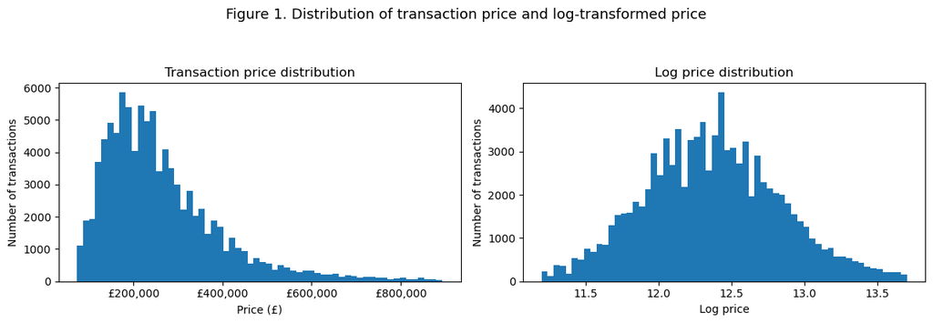

```python
fig, axes = plt.subplots(1, 2, figsize=(12, 4))

fig.suptitle(
    "Figure 1. Distribution of transaction price and log-transformed price",
    fontsize=13,
    y=1.02
)

axes[0].hist(model_df["price"], bins=60)
axes[0].set_title("Transaction price distribution")
axes[0].set_xlabel("Price (£)")
axes[0].set_ylabel("Number of transactions")
axes[0].xaxis.set_major_formatter(mtick.StrMethodFormatter("£{x:,.0f}"))

axes[1].hist(model_df["log_price"], bins=60)
axes[1].set_title("Log price distribution")
axes[1].set_xlabel("Log price")
axes[1].set_ylabel("Number of transactions")

plt.tight_layout(rect=[0, 0, 1, 0.95])
plt.show()
```

Figure 1 shows the difference between the original transaction price and its log-transformed version. The raw price distribution is heavily concentrated below about £300,000, but it has a long right tail. After the log transformation, the distribution becomes more balanced and less dominated by the upper tail. This makes it more suitable for regression analysis than the original price variable.

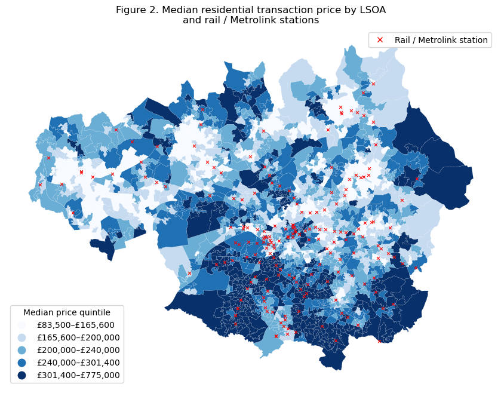

```python
LSOA_PATH = DATA_DIR / "LSOA_2021_boundary.gpkg"

lsoa_boundaries = gpd.read_file(LSOA_PATH).to_crs("EPSG:27700")


lsoa_price = (
    model_df
    .groupby("lsoa_code")
    .agg(
        median_price=("price", "median"),
        transactions=("price", "size")
    )
    .reset_index()
)


lsoa_map = lsoa_boundaries.merge(
    lsoa_price,
    left_on="LSOA21CD",
    right_on="lsoa_code",
    how="inner"
)


lsoa_map["price_quintile"] = pd.qcut(
    lsoa_map["median_price"],
    q=5,
    duplicates="drop"
)

price_labels = []

for interval in lsoa_map["price_quintile"].cat.categories:
    price_labels.append(
        f"£{interval.left:,.0f}–£{interval.right:,.0f}"
    )

lsoa_map["price_quintile"] = (
    lsoa_map["price_quintile"]
    .cat.rename_categories(price_labels)
)


stations_plot = stations_gdf.copy()

if stations_plot.crs is None:
    stations_plot = stations_plot.set_crs("EPSG:27700")
else:
    stations_plot = stations_plot.to_crs("EPSG:27700")


fig, ax = plt.subplots(figsize=(8.5, 8))

lsoa_map.plot(
    column="price_quintile",
    ax=ax,
    cmap="Blues",
    categorical=True,
    legend=True,
    edgecolor="white",
    linewidth=0.08,
    legend_kwds={
        "title": "Median price quintile",
        "loc": "lower left",
        "frameon": True
    }
)

price_legend = ax.get_legend()

stations_plot.plot(
    ax=ax,
    color="red",
    markersize=12,
    marker="x",
    linewidth=0.8
)

station_handle = Line2D(
    [0], [0],
    marker="x",
    color="red",
    linestyle="None",
    markersize=6,
    label="Rail / Metrolink station"
)

station_legend = ax.legend(
    handles=[station_handle],
    loc="upper right",
    frameon=True
)

ax.add_artist(price_legend)

ax.set_title(
    "Figure 2. Median residential transaction price by LSOA\n"
    "and rail / Metrolink stations",
    fontsize=12
)

ax.set_axis_off()

plt.tight_layout()
plt.show()
```

Figure 2 shows the spatial distribution of median residential transaction prices at LSOA level, with rail and Metrolink stations overlaid. Prices are grouped into quintiles, so each colour class contains roughly the same number of LSOAs rather than an equal price range. The map suggests a clear uneven housing market. Higher median prices are more visible in parts of the south and south-west, while lower-price areas appear more frequently across parts of the north, east and inner urban area. Rail and Metrolink stations are concentrated around central Manchester and along several radial corridors. However, the map does not show a simple link between station proximity and higher prices. The map therefore provides spatial context for the regression analysis, rather than direct evidence of a transport effect.

Taken together, the descriptive statistics and maps show that the dataset contains both statistical and spatial variation. Prices are unevenly distributed, station access differs across the region, and median prices vary noticeably between LSOAs. However, these patterns cannot show whether station distance is related to prices once other factors are considered. The next section therefore moves from description to modelling, using regression analysis to estimate the relationship between rail/Metrolink accessibility and residential prices.

## 5. Methodology: OLS and GWR

The analysis used two regression approaches. An Ordinary Least Squares (OLS) model was estimated at the transaction level to examine the average relationship between rail/Metrolink station distance and residential price across Greater Manchester. The dependent variable was log_price. The main explanatory variable was distance to the nearest rail or Metrolink station. The model also controlled for distance to Manchester city centre, neighbourhood deprivation, property type, new-build status, tenure and transaction year.

Robust standard errors were used to make the statistical inference less sensitive to heteroskedasticity. The OLS model is useful because it provides a single overall estimate of the station-distance relationship after controlling for other observed factors. However, it assumes that this relationship is the same across the whole study area.

For this reason, Geographically Weighted Regression (GWR) was used as a second, exploratory stage. GWR allows regression coefficients to vary across space, making it suitable for checking whether the station-distance relationship is spatially uneven. Unlike the OLS model, which was estimated using individual transactions, the GWR model was estimated at LSOA level after aggregating transaction records to neighbourhood units. This was done to make the local modelling more stable and easier to interpret. LSOAs with fewer than 20 transactions were excluded to reduce the risk of unstable local estimates. The GWR results should therefore be read as a neighbourhood-level spatial extension of the OLS analysis, rather than a direct replacement for it.

### 5.1 OLS Regression Results

```python
y_var = "log_price"

x_vars = [
    "nearest_station_dist_km",
    "city_centre_dist_km",
    "imd_deprivation_decile",
    "property_type_F",
    "property_type_S",
    "property_type_T",
    "old_new_Y",
    "duration_L",
    "transaction_year_2024",
    "transaction_year_2025"
]

missing_vars = [col for col in [y_var] + x_vars if col not in model_df.columns]

if missing_vars:
    raise ValueError(f"These variables are missing from model_df: {missing_vars}")


ols_df = model_df[[y_var] + x_vars].copy()

for col in [y_var] + x_vars:
    ols_df[col] = pd.to_numeric(ols_df[col], errors="coerce")


X = ols_df[x_vars]
X = sm.add_constant(X)

y = ols_df[y_var]

ols_model = sm.OLS(y, X).fit(cov_type="HC3")


ols_results_table = pd.DataFrame({
    "Variable": ols_model.params.index,
    "Coefficient": ols_model.params.values,
    "Robust SE": ols_model.bse.values,
    "p-value": ols_model.pvalues.values
})


ols_results_table = ols_results_table[
    ols_results_table["Variable"] != "const"
].copy()


ols_results_table["Approx. % effect"] = (
    100 * (np.exp(ols_results_table["Coefficient"]) - 1)
)

ols_results_table["p-value"] = ols_results_table["p-value"].apply(
    lambda p: "<0.001" if p < 0.001 else round(p, 3)
)

ols_results_table = ols_results_table.round({
    "Coefficient": 4,
    "Robust SE": 4,
    "Approx. % effect": 2
})

display(ols_results_table)


ols_fit_table = pd.DataFrame({
    "Measure": [
        "Observations",
        "R-squared",
        "Adjusted R-squared",
        "AIC",
        "BIC"
    ],
    "Value": [
        int(ols_model.nobs),
        round(ols_model.rsquared, 3),
        round(ols_model.rsquared_adj, 3),
        round(ols_model.aic, 1),
        round(ols_model.bic, 1)
    ]
})

display(ols_fit_table)
```

|  | Variable | Coefficient | Robust SE | p-value | Approx. % effect |
| --- | --- | --- | --- | --- | --- |
| 1 | nearest_station_dist_km | -0.0189 | 0.0010 | <0.001 | -1.87 |
| 2 | city_centre_dist_km | -0.0212 | 0.0002 | <0.001 | -2.10 |
| 3 | imd_deprivation_decile | -0.0670 | 0.0004 | <0.001 | -6.48 |
| 4 | property_type_F | -0.7803 | 0.0045 | <0.001 | -54.17 |
| 5 | property_type_S | -0.3284 | 0.0032 | <0.001 | -27.99 |
| 6 | property_type_T | -0.5223 | 0.0035 | <0.001 | -40.68 |
| 7 | old_new_Y | 0.2275 | 0.0038 | <0.001 | 25.55 |
| 8 | duration_L | -0.0925 | 0.0023 | <0.001 | -8.84 |
| 9 | transaction_year_2024 | 0.0344 | 0.0025 | <0.001 | 3.50 |
| 10 | transaction_year_2025 | 0.0719 | 0.0026 | <0.001 | 7.45 |

|  | Measure | Value |
| --- | --- | --- |
| 0 | Observations | 93842.000 |
| 1 | R-squared | 0.541 |
| 2 | Adjusted R-squared | 0.541 |
| 3 | AIC | 49553.000 |
| 4 | BIC | 49656.900 |

The table presents the OLS results for the transaction-level model. The coefficient for distance to the nearest rail or Metrolink station is negative and statistically significant. Holding the observed property and neighbourhood controls constant, an additional kilometre from the nearest station is associated with about a 1.87% lower transaction price. This suggests that rail-based accessibility has a measurable relationship with residential prices at the Greater Manchester scale, although the result should be read as an association rather than a causal effect.

The other spatial and neighbourhood controls also behave in expected directions. Greater distance from Manchester city centre is associated with lower prices, with an estimated effect of about 2.10% per additional kilometre. Higher deprivation is also strongly associated with lower prices: moving one decile higher on the deprivation scale is linked to an estimated 6.48% lower price. Property characteristics explain a substantial part of the variation. Flats, semi-detached and terraced properties are all priced lower than the omitted property-type category, while new-build properties have a positive coefficient. Leasehold properties are associated with lower prices than the tenure reference group. The year controls are positive for both 2024 and 2025, suggesting higher prices relative to 2023 after controlling for the other variables. Overall, the model explains a little over half of the variation in log prices, with an R-squared of 0.541.

### 5.2 Model Diagnostics

#### 5.2.1 VIF check

```python
from statsmodels.stats.outliers_influence import variance_inflation_factor

X_vif = ols_df[x_vars].copy()
X_vif = sm.add_constant(X_vif)

vif_table = pd.DataFrame({
    "Variable": X_vif.columns,
    "VIF": [
        variance_inflation_factor(X_vif.values, i)
        for i in range(X_vif.shape[1])
    ]
})

vif_table = vif_table[vif_table["Variable"] != "const"].copy()

vif_table = vif_table.sort_values("VIF", ascending=False)

vif_table["VIF"] = vif_table["VIF"].round(2)

display(vif_table)
```

|  | Variable | VIF |
| --- | --- | --- |
| 6 | property_type_T | 2.45 |
| 4 | property_type_F | 2.36 |
| 5 | property_type_S | 2.30 |
| 2 | city_centre_dist_km | 1.38 |
| 10 | transaction_year_2025 | 1.38 |
| 9 | transaction_year_2024 | 1.36 |
| 8 | duration_L | 1.28 |
| 1 | nearest_station_dist_km | 1.27 |
| 3 | imd_deprivation_decile | 1.14 |
| 7 | old_new_Y | 1.11 |

VIF values were low, with a maximum of 2.45, indicating no serious multicollinearity among the explanatory variables.

#### 5.2.2 residual diagnostics

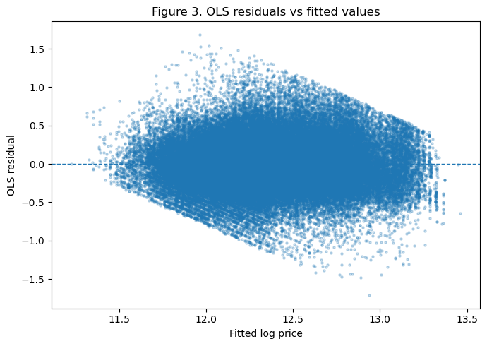

```python
ols_diag_df = ols_df.copy()
ols_diag_df["fitted_log_price"] = ols_model.fittedvalues
ols_diag_df["ols_residual"] = ols_model.resid
ols_diag_df["ols_std_residual"] = (
    ols_diag_df["ols_residual"] / ols_diag_df["ols_residual"].std()
)

plt.figure(figsize=(7, 5))

plt.scatter(
    ols_diag_df["fitted_log_price"],
    ols_diag_df["ols_residual"],
    s=5,
    alpha=0.25
)

plt.axhline(0, linestyle="--", linewidth=1)
plt.xlabel("Fitted log price")
plt.ylabel("OLS residual")
plt.title("Figure 3. OLS residuals vs fitted values")
plt.tight_layout()
plt.show()
```

Figure 3 plots the OLS residuals against fitted log prices. Most residuals are centred around zero, which suggests that the model is not consistently over- or under-predicting across the whole sample. However, the spread is not completely even. The cloud of points changes shape across the fitted values, with a wider spread around the middle of the fitted price range and a more compressed pattern at the upper end. This suggests some remaining heteroskedasticity or model structure not fully captured by the covariates. The use of robust standard errors helps with inference, but it does not remove the underlying pattern in the residuals.

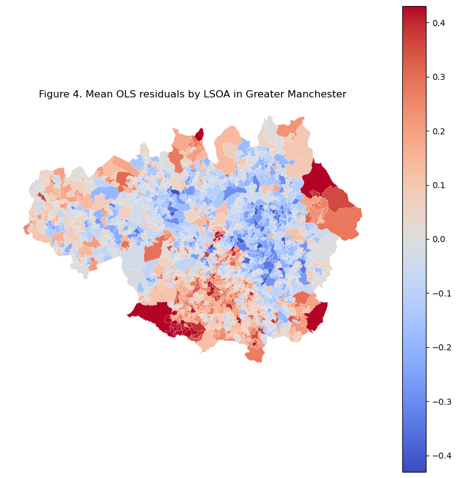

```python
model_resid_df = model_df.loc[ols_diag_df.index].copy()
model_resid_df["ols_residual"] = ols_diag_df["ols_residual"]
model_resid_df["ols_std_residual"] = ols_diag_df["ols_std_residual"]


lsoa_col_model = "lsoa_code"
lsoa_col_boundary = "LSOA21CD"

if lsoa_col_model not in model_resid_df.columns:
    raise ValueError(f"{lsoa_col_model} not found in model_df.")

if lsoa_col_boundary not in lsoa_boundaries.columns:
    raise ValueError(f"{lsoa_col_boundary} not found in lsoa_boundaries.")


lsoa_residuals = (
    model_resid_df
    .groupby(lsoa_col_model)
    .agg(
        mean_ols_residual=("ols_residual", "mean"),
        transactions=("ols_residual", "size")
    )
    .reset_index()
)


gm_lsoa_codes = set(lsoa_residuals[lsoa_col_model])

gm_lsoa_boundaries = lsoa_boundaries[
    lsoa_boundaries[lsoa_col_boundary].isin(gm_lsoa_codes)
].copy()

resid_map_gm = gm_lsoa_boundaries.merge(
    lsoa_residuals,
    left_on=lsoa_col_boundary,
    right_on=lsoa_col_model,
    how="left"
)


abs_limit = resid_map_gm["mean_ols_residual"].abs().quantile(0.98)

norm = TwoSlopeNorm(
    vmin=-abs_limit,
    vcenter=0,
    vmax=abs_limit
)

fig, ax = plt.subplots(figsize=(8, 8))

resid_map_gm.plot(
    column="mean_ols_residual",
    cmap="coolwarm",
    norm=norm,
    linewidth=0.1,
    edgecolor="white",
    legend=True,
    ax=ax
)

ax.set_title("Figure 4. Mean OLS residuals by LSOA in Greater Manchester")
ax.set_axis_off()

plt.tight_layout()
plt.show()
```

Figure 4 maps the mean OLS residual by LSOA. Positive residuals indicate areas where observed prices are higher than the model predicts, while negative residuals indicate areas where the model predicts prices above observed values. The map shows that residuals are not randomly scattered across space. Some clusters of positive residuals appear in parts of southern and outer Greater Manchester, while negative residuals are more visible in parts of the inner and north-eastern area. This suggests that the global OLS model misses some local spatial variation in house prices.

To assess this more formally, Moran’s I was then calculated for the OLS residuals.

```python
moran_gdf = resid_map_gm.dropna(subset=["mean_ols_residual"]).copy()
moran_gdf = moran_gdf[moran_gdf.geometry.notnull()].copy()

w = Queen.from_dataframe(moran_gdf, use_index=True)
w.transform = "r"

moran = Moran(
    moran_gdf["mean_ols_residual"],
    w,
    permutations=999
)

moran_table = pd.DataFrame({
    "Measure": [
        "Moran's I",
        "Pseudo p-value",
        "Number of LSOAs"
    ],
    "Value": [
        round(moran.I, 4),
        round(moran.p_sim, 4),
        len(moran_gdf)
    ]
})

display(moran_table)
```

|  | Measure | Value |
| --- | --- | --- |
| 0 | Moran's I | 0.594 |
| 1 | Pseudo p-value | 0.001 |
| 2 | Number of LSOAs | 1702.000 |

The LSOA-level residual map showed clear spatial clustering, which was confirmed by Moran’s I of 0.594 with a pseudo p-value of 0.001. This suggests that the OLS residuals are not spatially random, and that a single global coefficient may not fully capture local variation across Greater Manchester. GWR was therefore used as an exploratory extension to examine whether the station-distance relationship varies spatially.

### 5.3 GWR

The GWR model was used here to move beyond the average OLS estimate and examine whether the station-distance coefficient changes across neighbourhoods. Since the model was estimated at LSOA level, the results should be interpreted as spatial patterns in local neighbourhood-level associations, rather than transaction-level effects.

```python
lsoa_col_model = "lsoa_code"
lsoa_col_boundary = "LSOA21CD"

gwr_source_cols = [
    lsoa_col_model,
    "log_price",
    "nearest_station_dist_km",
    "city_centre_dist_km",
    "imd_deprivation_decile",
    "property_type_F",
    "property_type_S",
    "property_type_T",
    "old_new_Y",
    "duration_L"
]

missing_cols = [col for col in gwr_source_cols if col not in model_df.columns]

if missing_cols:
    raise ValueError(f"Missing columns in model_df: {missing_cols}")

if lsoa_col_boundary not in lsoa_boundaries.columns:
    raise ValueError(f"{lsoa_col_boundary} not found in lsoa_boundaries.")



gwr_source_df = model_df[gwr_source_cols].copy()

numeric_cols = [col for col in gwr_source_cols if col != lsoa_col_model]

for col in numeric_cols:
    gwr_source_df[col] = pd.to_numeric(gwr_source_df[col], errors="coerce")

gwr_source_df = gwr_source_df.dropna()


lsoa_gwr_data = (
    gwr_source_df
    .groupby(lsoa_col_model)
    .agg(
        median_log_price=("log_price", "median"),
        median_station_dist_km=("nearest_station_dist_km", "median"),
        median_city_centre_dist_km=("city_centre_dist_km", "median"),
        imd_deprivation_decile=("imd_deprivation_decile", "median"),
        prop_flat=("property_type_F", "mean"),
        prop_semi=("property_type_S", "mean"),
        prop_terraced=("property_type_T", "mean"),
        prop_new_build=("old_new_Y", "mean"),
        prop_leasehold=("duration_L", "mean"),
        transactions=("log_price", "size")
    )
    .reset_index()
)


gm_lsoa_boundaries = lsoa_boundaries[
    lsoa_boundaries[lsoa_col_boundary].isin(lsoa_gwr_data[lsoa_col_model])
].copy()

gm_lsoa_boundaries = gm_lsoa_boundaries.to_crs("EPSG:27700")

gwr_gdf = gm_lsoa_boundaries.merge(
    lsoa_gwr_data,
    left_on=lsoa_col_boundary,
    right_on=lsoa_col_model,
    how="inner"
)


min_transactions = 20

gwr_gdf = gwr_gdf[gwr_gdf["transactions"] >= min_transactions].copy()

gwr_gdf["centroid_x"] = gwr_gdf.geometry.centroid.x
gwr_gdf["centroid_y"] = gwr_gdf.geometry.centroid.y


gwr_y_var = "median_log_price"

gwr_x_vars = [
    "median_station_dist_km",
    "median_city_centre_dist_km",
    "imd_deprivation_decile",
    "prop_flat",
    "prop_semi",
    "prop_terraced",
    "prop_new_build",
    "prop_leasehold"
]

gwr_gdf = gwr_gdf.dropna(
    subset=[gwr_y_var] + gwr_x_vars + ["centroid_x", "centroid_y"]
).copy()
```

```python
gwr_y_var = "median_log_price"

gwr_x_vars = [
    "median_station_dist_km",
    "median_city_centre_dist_km",
    "imd_deprivation_decile",
    "prop_flat",
    "prop_semi",
    "prop_terraced",
    "prop_new_build",
    "prop_leasehold"
]


gwr_model_gdf = gwr_gdf.dropna(
    subset=[gwr_y_var] + gwr_x_vars + ["centroid_x", "centroid_y"]
).copy()

coords = gwr_model_gdf[["centroid_x", "centroid_y"]].values
y_gwr = gwr_model_gdf[[gwr_y_var]].values
X_gwr = gwr_model_gdf[gwr_x_vars].values


bw_selector = Sel_BW(
    coords,
    y_gwr,
    X_gwr,
    fixed=False,
    kernel="bisquare"
)

gwr_bw = bw_selector.search(
    criterion="AICc",
    bw_min=80
)


gwr_model = GWR(
    coords,
    y_gwr,
    X_gwr,
    bw=gwr_bw,
    fixed=False,
    kernel="bisquare",
    constant=True
)

gwr_results = gwr_model.fit()
```

```python
station_var = "median_station_dist_km"
station_param_index = gwr_x_vars.index(station_var) + 1

gwr_model_gdf["gwr_station_coef"] = gwr_results.params[:, station_param_index]

gwr_model_gdf["gwr_station_pct_effect"] = (
    100 * (np.exp(gwr_model_gdf["gwr_station_coef"]) - 1)
)

gwr_station_summary = pd.DataFrame({
    "Measure": [
        "LSOAs",
        "Adaptive bandwidth",
        "Minimum local effect (%)",
        "25th percentile (%)",
        "Median local effect (%)",
        "75th percentile (%)",
        "Maximum local effect (%)",
        "Negative local effects (%)",
        "Positive local effects (%)"
    ],
    "Value": [
        len(gwr_model_gdf),
        int(gwr_bw),
        round(gwr_model_gdf["gwr_station_pct_effect"].min(), 2),
        round(gwr_model_gdf["gwr_station_pct_effect"].quantile(0.25), 2),
        round(gwr_model_gdf["gwr_station_pct_effect"].median(), 2),
        round(gwr_model_gdf["gwr_station_pct_effect"].quantile(0.75), 2),
        round(gwr_model_gdf["gwr_station_pct_effect"].max(), 2),
        round((gwr_model_gdf["gwr_station_pct_effect"] < 0).mean() * 100, 1),
        round((gwr_model_gdf["gwr_station_pct_effect"] > 0).mean() * 100, 1)
    ]
})

display(gwr_station_summary)
```

|  | Measure | Value |
| --- | --- | --- |
| 0 | LSOAs | 1567.00 |
| 1 | Adaptive bandwidth | 107.00 |
| 2 | Minimum local effect (%) | -17.71 |
| 3 | 25th percentile (%) | -4.31 |
| 4 | Median local effect (%) | 0.54 |
| 5 | 75th percentile (%) | 2.76 |
| 6 | Maximum local effect (%) | 12.55 |
| 7 | Negative local effects (%) | 45.10 |
| 8 | Positive local effects (%) | 54.90 |

```
Using station GeoDataFrame: stations_gdf
Stations plotted: 190
```

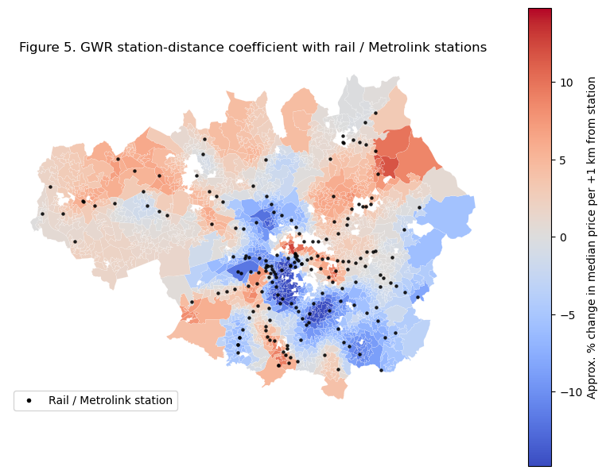

```python
possible_station_names = [
    "station_gdf",
    "stations_gdf",
    "stations",
    "rail_stations",
    "metrolink_stations",
    "rail_metrolink_stations",
    "stops_gdf",
    "metro_rail_stops"
]

station_gdf = None

for name in possible_station_names:
    if name in globals():
        obj = globals()[name]
        if isinstance(obj, gpd.GeoDataFrame):
            station_gdf = obj.copy()
            print(f"Using station GeoDataFrame: {name}")
            break

if station_gdf is None:
    raise NameError(
        "No station GeoDataFrame found. "
        "Set station_gdf = your station GeoDataFrame name before running this cell."
    )


if station_gdf.crs is None:
    raise ValueError("station_gdf has no CRS. Please set its CRS before plotting.")

station_gdf = station_gdf.to_crs(gwr_model_gdf.crs)


gm_boundary = gwr_model_gdf.geometry.union_all()

station_gdf_gm = station_gdf[
    station_gdf.geometry.intersects(gm_boundary.buffer(500))
].copy()

print(f"Stations plotted: {len(station_gdf_gm)}")


abs_limit = gwr_model_gdf["gwr_station_pct_effect"].abs().quantile(0.98)

norm = TwoSlopeNorm(
    vmin=-abs_limit,
    vcenter=0,
    vmax=abs_limit
)


fig, ax = plt.subplots(figsize=(8, 8))

gwr_model_gdf.plot(
    column="gwr_station_pct_effect",
    cmap="coolwarm",
    norm=norm,
    linewidth=0.1,
    edgecolor="white",
    legend=True,
    legend_kwds={
        "label": "Approx. % change in median price per +1 km from station",
        "shrink": 0.75
    },
    ax=ax
)

station_gdf_gm.plot(
    ax=ax,
    color="black",
    markersize=5,
    alpha=0.8
)

station_legend = Line2D(
    [0], [0],
    marker="o",
    color="w",
    label="Rail / Metrolink station",
    markerfacecolor="black",
    markersize=5
)

ax.legend(
    handles=[station_legend],
    loc="lower left",
    frameon=True
)

ax.set_title("Figure 5. GWR station-distance coefficient with rail / Metrolink stations")
ax.set_axis_off()

plt.tight_layout()
plt.show()
```

The GWR results suggest that the relationship between station distance and median house prices is spatially uneven. The model was estimated for 1,567 LSOAs with an adaptive bandwidth of 107, so each local estimate was based on nearby neighbourhoods rather than the full study area. The local station-distance effect ranges from -17.7% to 12.6% per additional kilometre, with a median close to zero. About 45% of LSOAs have negative local coefficients, while 55% have positive coefficients.

The map shows where this variation occurs. Negative coefficients, shown in blue, are most visible around the inner and south-central parts of Greater Manchester, with further blue areas extending towards the south-east. In these areas, greater distance from a rail or Metrolink station is associated with lower median prices. Positive coefficients, shown in red, appear more often in the outer west, north and north-east, where the relationship runs in the opposite direction. The station points are included only as a spatial reference, so the map should be read as local station-distance coefficients rather than direct station impacts. Overall, the GWR results suggest that the accessibility-price relationship is not uniform across Greater Manchester.

## 6. Summary of findings and suggestions

This project examined whether rail and Metrolink accessibility is associated with residential property prices in Greater Manchester, and whether this relationship varies across space. The results show that station proximity is relevant, but not in a simple or uniform way. In the OLS model, greater distance from the nearest rail or Metrolink station is associated with lower transaction prices after controlling for property type, tenure, new-build status, year, deprivation and distance to Manchester city centre. This suggests that rail-based accessibility is reflected in the housing market, although the size of the effect is modest compared with some property and neighbourhood characteristics.

The spatial analysis gives a more cautious picture. The residual clustering from the OLS model indicates that a single global coefficient does not fully capture the geography of prices in Greater Manchester. The GWR results show that the station-distance relationship changes across neighbourhoods. Negative local coefficients are more visible around the inner and south-central parts of the region, while positive coefficients appear more often in parts of the outer west, north and north-east. This means that accessibility is not automatically capitalised into prices in the same way everywhere.

The findings suggest that transport accessibility should be understood alongside wider urban context. For planning and housing analysis, station investment should not be assumed to produce the same housing-market response across all areas. Future work could improve the analysis by replacing straight-line distance with walking-network distance. Adding better property-level controls, such as floor area, number of bedrooms and dwelling condition, would also make the estimated accessibility relationship more reliable.

## 7. Limitations

Several limitations should be recognised. First, the analysis identifies associations rather than causal effects, so the results cannot prove that rail or Metrolink access directly changes house prices. Second, straight-line distance to the nearest station is a simplified measure of accessibility and does not capture walking routes, service frequency, fares or station quality. Third, Price Paid Data lacks important property attributes such as floor area, number of bedrooms and dwelling condition. Postcode coordinates also approximate property locations rather than exact addresses. Finally, the GWR results should be treated as exploratory because local coefficients may be sensitive to bandwidth choice and neighbourhood sample composition.

## 8. Reference list

Bowes, D.R. and Ihlanfeldt, K.R. (2001) ‘Identifying the impacts of rail transit stations on residential property values’, Journal of Urban Economics, 50(1), pp. 1–25. Available at: https://doi.org/10.1006/juec.2001.2214.

Fotheringham, A.S., Brunsdon, C. and Charlton, M. (2002) Geographically Weighted Regression: The Analysis of Spatially Varying Relationships. Chichester: Wiley. Available at: https://www.wiley.com/en-ie/Edition-p-9780470855256.

HM Land Registry (2026) Price Paid Data. Available at: https://www.gov.uk/government/statistical-data-sets/price-paid-data-downloads.

Ministry of Housing, Communities and Local Government (2025) English indices of deprivation 2025. Available at: https://www.gov.uk/government/statistics/english-indices-of-deprivation-2025.

Office for National Statistics (2024) Lower layer Super Output Areas (December 2021) Boundaries EW BGC (V5). Available at: https://www.data.gov.uk/dataset/40129cd8-4ebd-4a96-9625-869103493b28/lower-layer-super-output-areas-december-2021-boundaries-ew-bgc-v5.

Office for National Statistics (2025a) ONS Postcode Directory (May 2025) for the UK. Available at: https://geoportal.statistics.gov.uk/datasets/3be72478d8454b59bb86ba97b4ee325b.

Office for National Statistics (2025b) Local Authority Districts (December 2024) Boundaries UK BFC. Available at: https://www.data.gov.uk/dataset/02fd4563-a97b-47c3-9c06-8e7379d25b06/local-authority-districts-december-2024-boundaries-uk-bfc.

Rosen, S. (1974) ‘Hedonic prices and implicit markets: Product differentiation in pure competition’, Journal of Political Economy, 82(1), pp. 34–55. Available at: https://doi.org/10.1086/260169.

Transport for Greater Manchester (2024) Metrolink Stops and Rail Stations. Available at: https://www.data.gov.uk/dataset/8faea7ee-eb7d-43dd-b1d4-f01aac4c44d3/metrolink-and-rail-stations.

Wong, C., Schulze Baing, A., Shakeri, M. and Smith, J. (2015) Does space matter? Housing, transport and accessibility in GM. Manchester: School of Environment, Education and Development, The University of Manchester. Available at: https://documents.manchester.ac.uk/display.aspx?DocID=24969.

## 9. Word count

````python
import json
import re
from pathlib import Path

NOTEBOOK_PATH = Path("3149531_URBAN5160.ipynb")

REFERENCE_HEADINGS = {
    "references",
    "reference list",
    "bibliography"
}

def is_reference_heading(line):
    text = line.strip().lower()

    text = re.sub(r"^#+\s*", "", text)

    text = re.sub(r"^\d+(?:\.\d+)*\.?\s*", "", text)

    return text in REFERENCE_HEADINGS

def clean_markdown_text(text):
    lines = text.splitlines()
    cleaned_lines = []
    in_code_block = False

    for line in lines:
        stripped = line.strip()

        if is_reference_heading(stripped):
            return "\n".join(cleaned_lines), True

        if stripped.startswith("```"):
            in_code_block = not in_code_block
            continue
        if in_code_block:
            continue

        if stripped.startswith("#"):
            continue

        if "|" in stripped and len(stripped.split("|")) >= 3:
            continue

        if stripped.startswith("!["):
            continue

        cleaned_lines.append(line)

    return "\n".join(cleaned_lines), False

def count_words(text):
    text = re.sub(r"https?://\S+", " ", text)

    text = re.sub(r"`[^`]*`", " ", text)

    text = re.sub(r"<[^>]+>", " ", text)

    words = re.findall(r"\b[A-Za-z]+(?:-[A-Za-z]+)?\b", text)
    return len(words)

with open(NOTEBOOK_PATH, "r", encoding="utf-8") as f:
    nb = json.load(f)

total_words = 0

for cell in nb["cells"]:
    if cell.get("cell_type") != "markdown":
        continue

    source = cell.get("source", "")
    if isinstance(source, list):
        source = "".join(source)

    cleaned_text, reached_references = clean_markdown_text(source)

    if cleaned_text.strip():
        total_words += count_words(cleaned_text)

    if reached_references:
        break

print(f"Word count: {total_words}")
````

```
Word count: 2597
```